# Classification of Metamorphic Rocks

Dr. Ahmad Redaa

2024-10-14

# Introduction

- **Metamorphic rocks** are formed from pre-existing rocks through heat, pressure, and chemically active fluids.
- **Classification** is based on texture and mineral composition.
- Two main categories: **Foliated** and **Non-foliated** rocks.
- Note: Metamorphic rocks generally do not have specific names; they are usually descriptive.

# Foliated Metamorphic Rocks

1. Slate
2. Phyllite
3. Schist
4. Gneiss
- **Foliation**: Planar arrangement of mineral grains, giving the rock a layered or banded appearance.

# Slate

- **Texture**: Very fine-grained, slaty cleavage.
- **Common minerals**: Quartz, mica, chlorite.
- **Description**: Derived from shale; low-grade metamorphism.

[figure not shown]

Source: [https://openpress.usask.ca](https://openpress.usask.ca/physicalgeology/chapter/10-2-classification-of-metamorphic-rocks-2/)

# Phyllite

- **Texture**: Fine-grained, wavy surfaces with a sheen.
- **Common minerals**: Mica, quartz, chlorite.
- **Description**: Higher grade than slate; has a silky sheen due to fine mica flakes.

[figure not shown]

Source: [https://openpress.usask.ca](https://openpress.usask.ca/physicalgeology/chapter/10-2-classification-of-metamorphic-rocks-2/)

# Schist

- **Texture**: Medium to coarse-grained, schistosity (visible foliation).
- **Common minerals**: Mica, quartz, feldspar, garnet.
- **Description**: Higher grade than phyllite; often has large mica grains.

[figure not shown]

Source: [https://openpress.usask.ca](https://openpress.usask.ca/physicalgeology/chapter/10-2-classification-of-metamorphic-rocks-2/)

# Gneiss

- **Texture**: Coarse-grained, banding of light and dark minerals (gneissic texture).
- **Common minerals**: Quartz, feldspar, biotite, amphibole.
- **Description**: High-grade metamorphic rock; distinct mineral banding.

[figure not shown]

Source: [https://openpress.usask.ca](https://openpress.usask.ca/physicalgeology/chapter/10-2-classification-of-metamorphic-rocks-2/)

# Non-foliated Metamorphic Rocks

- **Non-foliated texture**: No preferred orientation of mineral grains.

# Marble

- **Texture**: Coarse-grained, granular.
- **Common minerals**: Calcite or dolomite.
- **Description**: Derived from limestone; reacts with acid.

[figure not shown]

Source: [https://openpress.usask.ca](https://openpress.usask.ca/physicalgeology/chapter/10-2-classification-of-metamorphic-rocks-2/)

# Quartzite

- **Texture**: Medium to coarse-grained, interlocking quartz grains.
- **Common minerals**: Quartz.
- **Description**: Derived from sandstone; very hard and resistant to weathering.

[figure not shown]

Source: [https://openpress.usask.ca](https://openpress.usask.ca/physicalgeology/chapter/10-2-classification-of-metamorphic-rocks-2/)

# Hornfels

- **Texture**: Fine-grained, dense, and hard.
- **Common minerals**: Variable, often with biotite, feldspar, and pyroxene.
- **Description**: Formed by contact metamorphism; lacks foliation.

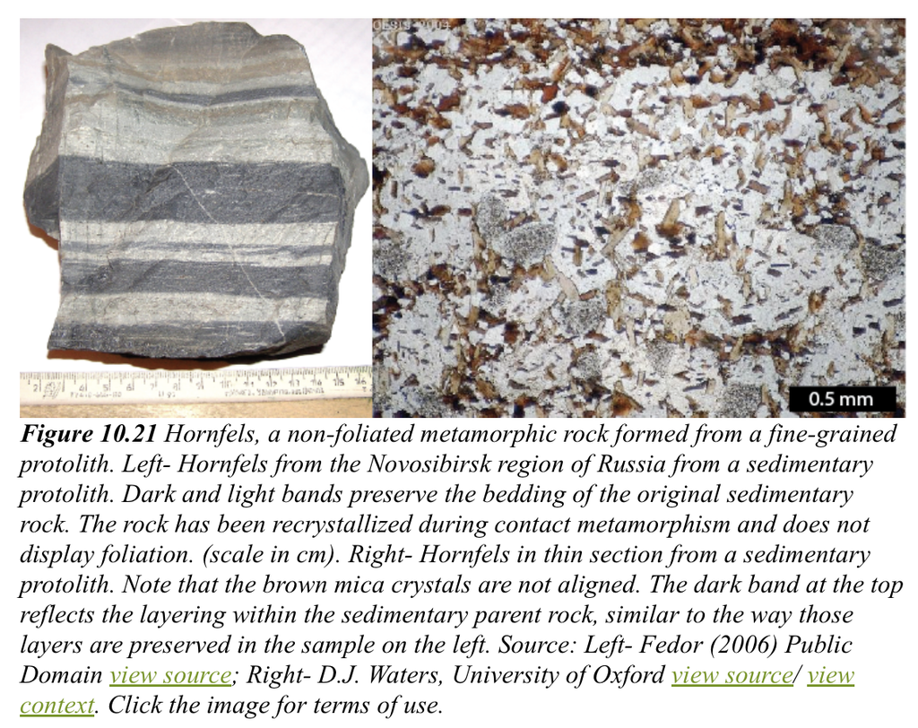

Source: [https://openpress.usask.ca](https://openpress.usask.ca/physicalgeology/chapter/10-2-classification-of-metamorphic-rocks-2/)

# Metamorphic Rock Names

- **Descriptive Naming**: Metamorphic rocks do not have fixed names.
- Rock names generally describe the **texture** and **mineral composition**.
- Example: Biotite schist, Staurolite-Garnet-Mica Schist … etc

# Classification based on protolith composition (original rock)

- Each category in this classifications represents a specific chemical and mineralogical composition of the protolith
- Six primary classes:
  - Pelites
  - Psammites
  - Calcareous rocks
  - Quartzo-Feldspathic rocks
  - Mafic rocks
  - Ultramafic rocks

# Pelites

- **Protolith**: Mudstone, shale (clay-rich)
- **Composition**: High in **aluminum**
- **Common Metamorphic Minerals**: Mica, garnet, kyanite, sillimanite
- **Examples**:
  - **Before Metamorphism**: Shale, mudstone
  - **After Metamorphism**: Slate, phyllite, schist, gneiss

# Psammites

- **Protolith**: Sandstone (quartz-rich)
- **Composition**: High in **silica** (quartz, feldspar)
- **Common Metamorphic Rocks**: Quartzite, meta-sandstone
- **Examples**:
  - **Before Metamorphism**: Sandstone
  - **After Metamorphism**: Quartzite, meta-sandstone

# Calcareous Rocks

- **Protolith**: Limestone, dolostone (carbonate-rich)
- **Composition**: High in **calcium carbonate**
- **Common Metamorphic Minerals**: Calcite, dolomite, diopside, wollastonite
- **Examples**:
  - **Before Metamorphism**: Limestone, dolostone
  - **After Metamorphism**: Marble, calc-silicate rock

# Quartzo-Feldspathic Rocks

- **Protolith**: Granitic rocks, arkosic sandstones
- **Composition**: High in **quartz and feldspar**
- **Common Metamorphic Rocks**: Gneiss, granulite
- **Examples**:
  - **Before Metamorphism**: Granite, arkosic sandstone
  - **After Metamorphism**: Gneiss, granulite

# Mafic Rocks

- **Protolith**: Basalt, gabbro (iron and magnesium-rich)
- **Composition**: Moderate silica, high **iron and magnesium**
- **Common Metamorphic Minerals**: Amphibole, pyroxene, plagioclase
- **Examples**:
  - **Before Metamorphism**: Basalt, gabbro
  - **After Metamorphism**: Amphibolite, granulite

# Ultramafic Rocks

- **Protolith**: Peridotite (low silica, high magnesium and iron)
- **Composition**: Very low **silica**, high **Mg** and **Fe**
- **Common Metamorphic Minerals**: Olivine, serpentine, talc
- **Examples**:
  - **Before Metamorphism**: Peridotite
  - **After Metamorphism**: Serpentinite, talc-schist

# Summary Table

- Metamorphic rock classification reflects original rock composition.
- Protoliths influence mineral assemblages, textures, and final rock type.
- Recognizing these classes aids in interpreting metamorphic processes and conditions.

[output not shown]

# Another Genetic Classification

## Para- Metamorphic Rocks

- **Prefix “Para-”**: Indicates a **sedimentary protolith**.
- **Examples**:
  - **Para-schist**: Derived from shale or mudstone.
  - **Para-gneiss**: Originates from sandstone or siltstone.
- **Characteristics**: May retain sedimentary features, such as layering.

## Ortho- Metamorphic Rocks

- **Prefix “Ortho-”**: Indicates an **igneous protolith**.
- **Examples**:
  - **Ortho-gneiss**: Derived from granite or granodiorite.
  - **Ortho-amphibolite**: Originates from basalt or gabbro.
- **Characteristics**: May retain igneous minerals and textures.